# result_mfilippovskii

## Решение задачи прогнозирования оттока услуг

### Подключение необходимых библиотек

**numpy** для использования математических методов

**pandas** для удобства работы с данными и их отображением

**sklearn** для использования моделей и их метрик

**matplotlib** для визуализации

**jupyterthemes** для красоты

```python
import numpy as np
import pandas as pd
import sklearn
from sklearn.metrics import roc_curve, auc, roc_auc_score, roc_auc_score

from sklearn.linear_model import LogisticRegression
from sklearn.naive_bayes import GaussianNB
from sklearn.tree import DecisionTreeClassifier
from sklearn.neighbors import KNeighborsClassifier, NearestCentroid
from sklearn import svm
from sklearn.neural_network import MLPClassifier
from sklearn.ensemble import RandomForestClassifier
from sklearn.ensemble import AdaBoostClassifier
from sklearn.ensemble import GradientBoostingClassifier

from sklearn.metrics import classification_report
from datetime import datetime, timedelta

%matplotlib inline
import matplotlib
from matplotlib import pyplot as plt
plt.rcParams['figure.figsize'] = (10, 10)
from IPython.display import display

# стилизация графиков под тему выбранную с помощью jupyterthemes (если не установлен
# jupyterthemes можно удалить строки между коментариями)
from jupyterthemes import jtplot
jtplot.style()
# ;

import sys
print(pd.__version__)
print(sys.version)
print("Python runned:", sys.executable)
```

```
0.25.1
3.7.3 (default, Mar 27 2019, 22:11:17)
[GCC 7.3.0]
Python runned: /home/unit/anaconda3/bin/python
```

## Прочитаем данные и сформируем тестовую и обучающую выборки

Данные делим с помощью скрипта, приложенного к задаче

```python
# чтение данных
# история транзакций
df_history = pd.read_csv("history.csv", parse_dates=["pay_date", "start_date", "expiration_date", "on_date"])
# отложенная выборка
df_test = pd.read_csv("test.csv", parse_dates=["on_date"])
# информация о клиентах
df_users = pd.read_csv("users.csv")

# выделение признаков из истории транзакций по конкретной услуге
def get_features(df):
    df["cumsum_amount"] = df["amount"].cumsum()
    return df
# сортировка по времени, группировка по услугам, выделение признаков
df_history = df_history\
    .sort_values(["service_id", "pay_date", "start_date"])\
    .groupby("service_id")\
    .apply(get_features)

# разделение истории на обучающую и тестовую выборку
df_history["test"] = df_history["churn"].isnull()

# используемые признаки
used_cols = ["nth_renewal", "cumsum_amount"]
# целевой признак
target_col = "churn"

# обучающая выборка
X_train = df_history.query("~test")[used_cols]
y_train = df_history.query("~test")[target_col]
# тестовая (отложенная) выборка
X_test = df_history.query("test")[used_cols]
y_test = df_test[target_col]
```

Посмотрим, что из себя представляют данные и распределены классы в обучающей выборке

```python
X_train.head(10)
```

|  | nth_renewal | cumsum_amount |
| --- | --- | --- |
| 1876 | 0 | 1 |
| 1877 | 0 | 3 |
| 1878 | 1 | 4 |
| 1879 | 2 | 5 |
| 1880 | 3 | 6 |
| 1881 | 4 | 7 |
| 1882 | 5 | 8 |
| 1883 | 6 | 9 |
| 1884 | 7 | 10 |
| 1885 | 0 | 1 |

```
Распределение классов в обучающей выборке
```

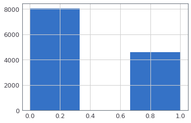

```python
print('Распределение классов в обучающей выборке')
plt.hist(y_train.values, bins=3)
plt.show()
```

```
Распределение классов в тестовой выборке
```

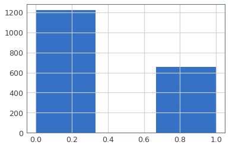

```python
print("Распределение классов в тестовой выборке")
plt.hist(y_test.values.astype(np.int32), bins=3)
plt.show()
```

## Выбор моделей и методов оценки

Для решения текущей задачи попробуем такие модели как: *Logistic Regression, Nearest Neighbors, Naive Bayes, Decision Trees, Ada Boost Random Forest* и ради интереса попробуем *Multi-Layer Perceptron*.

Для оценки будем использовать такие метрики как: *AUC-ROC*, а так же *precision, recall* и *f1-score* из sklearn.metrics classification_report. Посмотрим на результаты и выберем подходящее решение для данной задачи.

Ошибка в предсказании положительного класса (уходящие клиенты) может привести к потере клиента, поскольку в этом случае мы не применим меры по его удержанию. С другой стороны, ошибка в предсказании отрицательного класса, повлечет за собой дополнительные расходы по удержанию клиента. Однако, в последнем случае, стоимость мер по удержанию, вероятно, будет значительно меньше недополученной прибыли от ушедшего клиента.

Учитывая вышесказанное, при оценке модели прежде всего будем опираться на метрики precision положительного класса и f1-score положительного класса. Кроме того, для общей оценки модели будем использовать AUC-ROC score.

Напишем функции для оценки и построения графиков

**draw_roc_auc** - строит ROC-кривую, которая показывает зависимость true positive rate от false positive rate

**draw_feature_importance** - строит график, который отображает важность для обученной модели

**classification_metrics_report** - отображает рассчитанные оценки precision, recall, f1-score

А так же создадим словарь *all_metrics*, в который будем собирать с помощью *classification_metrics_report* все нужные показатели метрик, чтобы потом сравнить модели все вместе

```python
all_metrics = {}

def draw_roc_auc(clf, X_test, y_test, modelname = None, acc_score = None):
    fpr, tpr, thresholds = roc_curve(y_test, clf.predict_proba(X_test)[:,1])

    plt.rcParams["figure.figsize"] = [10,10]

    plt.plot(fpr, tpr)
    plt.plot([0.0, 1.0], [0.0, 1.0], ls='--', color="green")

    plt.xlabel("False Positive Rate")
    plt.ylabel("True Positive Rate")
    auc_score = auc(fpr, tpr)

    if (modelname and acc_score):
        print("Accuracy of {} model on test data: {}".format(modelname, acc_score))

        if (not all_metrics.get(modelname)):
            all_metrics[modelname] = {}

        all_metrics[modelname]['AUC'] = auc_score
        all_metrics[modelname]['ACC'] = acc_score

    plt.title("AUC Score: {}".format(auc_score))

    plt.show()

def draw_feature_importance(feature_importances, columns, modelname):
    matplotlib.rcParams['figure.figsize'] = (8.0, 8.0)

    feature_importances = pd.Series(feature_importances.reshape(-1), index=columns)
    feature_importances = feature_importances.sort_values()
    print(feature_importances)
    feature_importances.plot(kind = "barh")

    plt.title("Feature importance for {} Model".format(modelname))
    plt.show()

def classification_metrics_report(X_test, X_train, y_test, y_train, modelname, is_add_all_metrics):
    X_test_predictions = clf.predict(X_test)
    X_train_predictions = clf.predict(X_train)

    target_names = ["negative class", "positive class"]
    test_report = classification_report(
        y_test,
        X_test_predictions,
        target_names=target_names,
        output_dict=True
    )
    train_report = classification_report(
        y_train,
        X_train_predictions,
        target_names=target_names,
        output_dict=True
    )
    if (is_add_all_metrics):
        all_metrics[modelname]['test_p'] = test_report['positive class']
        all_metrics[modelname]['test_n'] = test_report['negative class']
        all_metrics[modelname]['train_p'] = test_report['positive class']
        all_metrics[modelname]['train_n'] = test_report['negative class']

    print("\nTest data:")
    display(pd.DataFrame.from_dict(test_report).T)

    print("\nTrain data:")
    display(pd.DataFrame.from_dict(train_report).T)
```

## Logistic regression

```
Accuracy of Logistic Regression model on test data: 0.6577825159914712
```

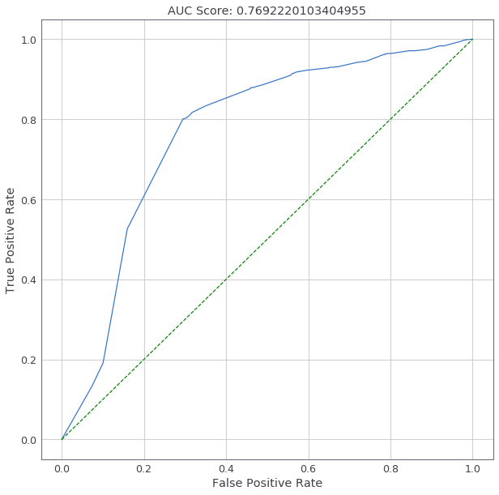

```
nth_renewal     -0.558044
cumsum_amount    0.016250
dtype: float64
```

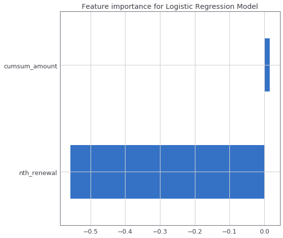

```python
modelname = "Logistic Regression"

class_weight = {0: 0.5, 1: 1.0}

clf = LogisticRegression(max_iter=1000,
                         random_state=100,
                         C=0.01,
                         tol=1e-4,
                         penalty="l2",
                         class_weight=class_weight,
                         warm_start=False,
                         solver='liblinear') # solver: {‘newton-cg’, ‘lbfgs’, ‘liblinear’, ‘sag’, ‘saga’}
clf.fit(X_train, y_train)

score = clf.score(X_test, y_test)

draw_roc_auc(clf, X_test, y_test, modelname, score)
draw_feature_importance(clf.coef_, X_test.columns, modelname)
```

#### Classification metrics

```python
classification_metrics_report(X_test, X_train, y_test, y_train, modelname, True)
```

```
Test data:
```

|  | precision | recall | f1-score | support |
| --- | --- | --- | --- | --- |
| negative class | 0.890836 | 0.540917 | 0.673116 | 1222.000000 |
| positive class | 0.505291 | 0.876147 | 0.640940 | 654.000000 |
| accuracy | 0.657783 | 0.657783 | 0.657783 | 0.657783 |
| macro avg | 0.698063 | 0.708532 | 0.657028 | 1876.000000 |
| weighted avg | 0.756429 | 0.657783 | 0.661899 | 1876.000000 |

```
Train data:
```

|  | precision | recall | f1-score | support |
| --- | --- | --- | --- | --- |
| negative class | 0.872741 | 0.443906 | 0.588487 | 8049.000000 |
| positive class | 0.477042 | 0.886838 | 0.620375 | 4604.000000 |
| accuracy | 0.605074 | 0.605074 | 0.605074 | 0.605074 |
| macro avg | 0.674891 | 0.665372 | 0.604431 | 12653.000000 |
| weighted avg | 0.728759 | 0.605074 | 0.600090 | 12653.000000 |

## Naive Bayes

```
Accuracy of Naive Bayes model on test data: 0.6812366737739872
```

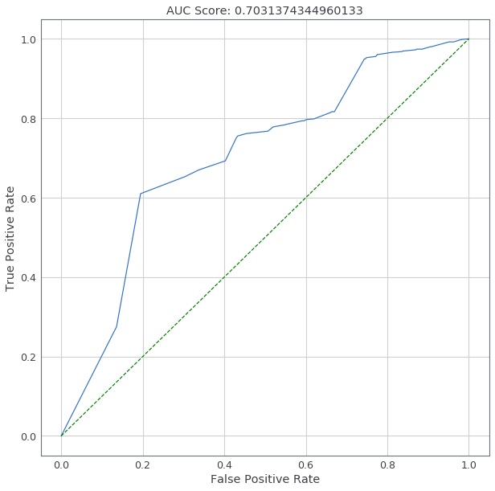

```python
modelname = "Naive Bayes"

clf = GaussianNB()
clf.fit(X_train, y_train)

score = clf.score(X_test, y_test)

draw_roc_auc(clf, X_test, y_test, modelname, score)
```

#### Classification metrics

```python
classification_metrics_report(X_test, X_train, y_test, y_train, modelname, True)
```

```
Test data:
```

|  | precision | recall | f1-score | support |
| --- | --- | --- | --- | --- |
| negative class | 0.789425 | 0.696399 | 0.740000 | 1222.000000 |
| positive class | 0.535088 | 0.652905 | 0.588154 | 654.000000 |
| accuracy | 0.681237 | 0.681237 | 0.681237 | 0.681237 |
| macro avg | 0.662256 | 0.674652 | 0.664077 | 1876.000000 |
| weighted avg | 0.700759 | 0.681237 | 0.687064 | 1876.000000 |

```
Train data:
```

|  | precision | recall | f1-score | support |
| --- | --- | --- | --- | --- |
| negative class | 0.836984 | 0.526898 | 0.646691 | 8049.000000 |
| positive class | 0.498023 | 0.820591 | 0.619852 | 4604.000000 |
| accuracy | 0.633763 | 0.633763 | 0.633763 | 0.633763 |
| macro avg | 0.667504 | 0.673744 | 0.633272 | 12653.000000 |
| weighted avg | 0.713648 | 0.633763 | 0.636925 | 12653.000000 |

## Decision Trees

```
Accuracy of Decision Tree model on test data: 0.7372068230277186
```

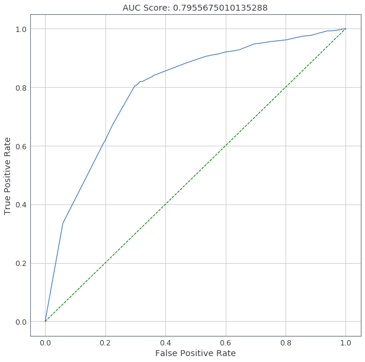

```
cumsum_amount    0.018579
nth_renewal      0.981421
dtype: float64
```

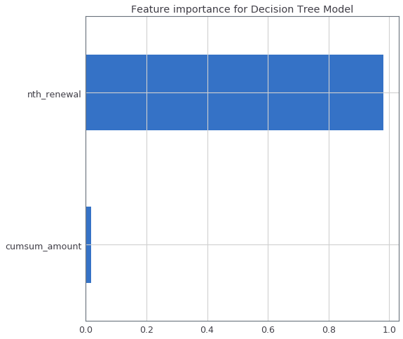

```python
modelname = "Decision Tree"

clf = DecisionTreeClassifier(random_state=100)
clf.fit(X_train, y_train)

score = clf.score(X_test, y_test)

draw_roc_auc(clf, X_test, y_test, modelname, score)
draw_feature_importance(clf.feature_importances_, X_test.columns, modelname)
```

#### Classification metrics

```python
classification_metrics_report(X_test, X_train, y_test, y_train, modelname, True)
```

```
Test data:
```

|  | precision | recall | f1-score | support |
| --- | --- | --- | --- | --- |
| negative class | 0.794189 | 0.805237 | 0.799675 | 1222.000000 |
| positive class | 0.626374 | 0.610092 | 0.618125 | 654.000000 |
| accuracy | 0.737207 | 0.737207 | 0.737207 | 0.737207 |
| macro avg | 0.710281 | 0.707665 | 0.708900 | 1876.000000 |
| weighted avg | 0.735686 | 0.737207 | 0.736384 | 1876.000000 |

```
Train data:
```

|  | precision | recall | f1-score | support |
| --- | --- | --- | --- | --- |
| negative class | 0.823251 | 0.669524 | 0.738472 | 8049.000000 |
| positive class | 0.564434 | 0.748697 | 0.643637 | 4604.000000 |
| accuracy | 0.698332 | 0.698332 | 0.698332 | 0.698332 |
| macro avg | 0.693843 | 0.709110 | 0.691055 | 12653.000000 |
| weighted avg | 0.729076 | 0.698332 | 0.703965 | 12653.000000 |

## Nearest Neighbors

```
Accuracy of KNearest Neighbors model on test data: 0.7164179104477612
```

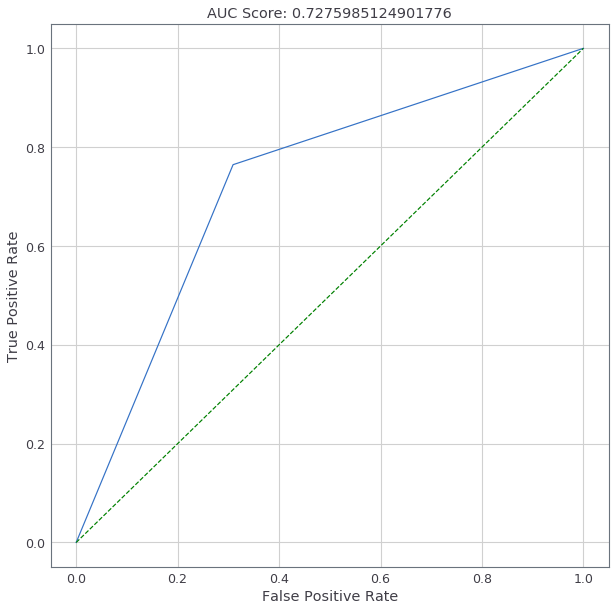

```python
modelname = "KNearest Neighbors"

clf = KNeighborsClassifier(n_neighbors=1)
clf.fit(X_train, y_train)

score = clf.score(X_test, y_test)

draw_roc_auc(clf, X_test, y_test, modelname, score)
```

#### Classification metrics

```python
classification_metrics_report(X_test, X_train, y_test, y_train, modelname, True)
```

```
Test data:
```

|  | precision | recall | f1-score | support |
| --- | --- | --- | --- | --- |
| negative class | 0.845691 | 0.690671 | 0.760360 | 1222.000000 |
| positive class | 0.569476 | 0.764526 | 0.652742 | 654.000000 |
| accuracy | 0.716418 | 0.716418 | 0.716418 | 0.716418 |
| macro avg | 0.707584 | 0.727599 | 0.706551 | 1876.000000 |
| weighted avg | 0.749399 | 0.716418 | 0.722843 | 1876.000000 |

```
Train data:
```

|  | precision | recall | f1-score | support |
| --- | --- | --- | --- | --- |
| negative class | 0.829557 | 0.618586 | 0.708704 | 8049.000000 |
| positive class | 0.538415 | 0.777802 | 0.636339 | 4604.000000 |
| accuracy | 0.676519 | 0.676519 | 0.676519 | 0.676519 |
| macro avg | 0.683986 | 0.698194 | 0.672522 | 12653.000000 |
| weighted avg | 0.723620 | 0.676519 | 0.682373 | 12653.000000 |

## SVM

```
Accuracy of SVM model on test data: 0.6577825159914712
```

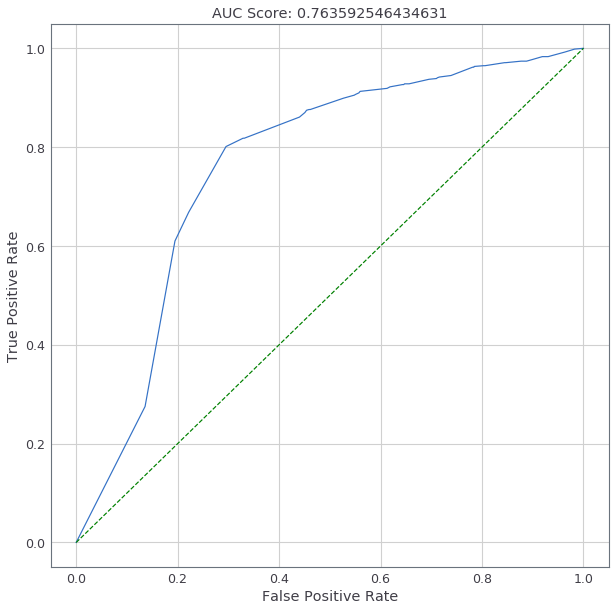

```python
modelname = "SVM"

clf = svm.SVC(gamma='scale',kernel='linear',random_state=100,probability=True, class_weight=class_weight)
clf.fit(X_train, y_train)

score = clf.score(X_test, y_test)

draw_roc_auc(clf, X_test, y_test, modelname, score)
```

#### Classification metrics

```python
classification_metrics_report(X_test, X_train, y_test, y_train, modelname, True)
```

```
Test data:
```

|  | precision | recall | f1-score | support |
| --- | --- | --- | --- | --- |
| negative class | 0.890836 | 0.540917 | 0.673116 | 1222.000000 |
| positive class | 0.505291 | 0.876147 | 0.640940 | 654.000000 |
| accuracy | 0.657783 | 0.657783 | 0.657783 | 0.657783 |
| macro avg | 0.698063 | 0.708532 | 0.657028 | 1876.000000 |
| weighted avg | 0.756429 | 0.657783 | 0.661899 | 1876.000000 |

```
Train data:
```

|  | precision | recall | f1-score | support |
| --- | --- | --- | --- | --- |
| negative class | 0.872741 | 0.443906 | 0.588487 | 8049.000000 |
| positive class | 0.477042 | 0.886838 | 0.620375 | 4604.000000 |
| accuracy | 0.605074 | 0.605074 | 0.605074 | 0.605074 |
| macro avg | 0.674891 | 0.665372 | 0.604431 | 12653.000000 |
| weighted avg | 0.728759 | 0.605074 | 0.600090 | 12653.000000 |

## MLP

```
Accuracy of MLP model on test data: 0.7398720682302772
```

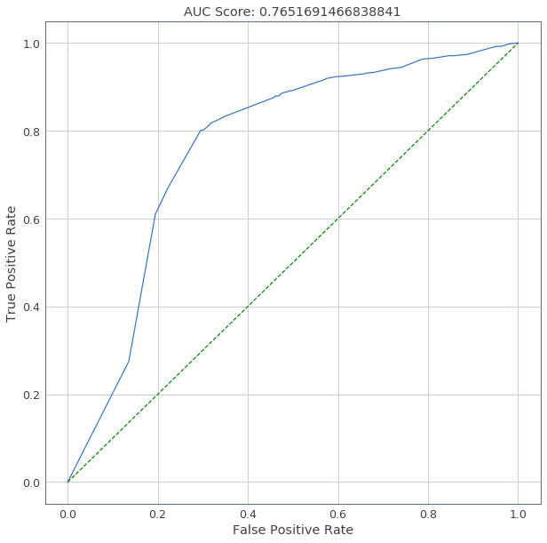

```python
modelname = 'MLP'

clf = MLPClassifier(hidden_layer_sizes=(100,50),
                    activation='logistic', #'logistic',# 'relu'
                    solver='adam',#'adam', 'sgd'
                    alpha=0.0001,
                    batch_size='auto',
                    learning_rate='invscaling',# 'constant', 'adaptive', 'invscaling'
                    learning_rate_init=0.05,
                    power_t=0.5,
                    max_iter=100000,
                    shuffle=True,
                    random_state=None,
                    tol=0.001,
                    verbose=False,
                    warm_start=True,
                    momentum=0.9,
                    nesterovs_momentum=True,
                    early_stopping=False,
                    validation_fraction=0.1,
                    beta_1=0.9,
                    beta_2=0.999,
                    epsilon=1e-08)

clf.fit(X_train, y_train)
score = clf.score(X_test, y_test)

draw_roc_auc(clf, X_test, y_test, modelname, score)
```

#### Classification metrics

```python
classification_metrics_report(X_test, X_train, y_test, y_train, modelname, True)
```

```
Test data:
```

|  | precision | recall | f1-score | support |
| --- | --- | --- | --- | --- |
| negative class | 0.814212 | 0.778232 | 0.795816 | 1222.000000 |
| positive class | 0.617232 | 0.668196 | 0.641703 | 654.000000 |
| accuracy | 0.739872 | 0.739872 | 0.739872 | 0.739872 |
| macro avg | 0.715722 | 0.723214 | 0.718760 | 1876.000000 |
| weighted avg | 0.745542 | 0.739872 | 0.742090 | 1876.000000 |

```
Train data:
```

|  | precision | recall | f1-score | support |
| --- | --- | --- | --- | --- |
| negative class | 0.837228 | 0.649894 | 0.731762 | 8049.00000 |
| positive class | 0.560031 | 0.779105 | 0.651649 | 4604.00000 |
| accuracy | 0.696910 | 0.696910 | 0.696910 | 0.69691 |
| macro avg | 0.698630 | 0.714500 | 0.691705 | 12653.00000 |
| weighted avg | 0.736365 | 0.696910 | 0.702611 | 12653.00000 |

## Random Forest

```
Accuracy of Random Forest model on test data: 0.7372068230277186
```

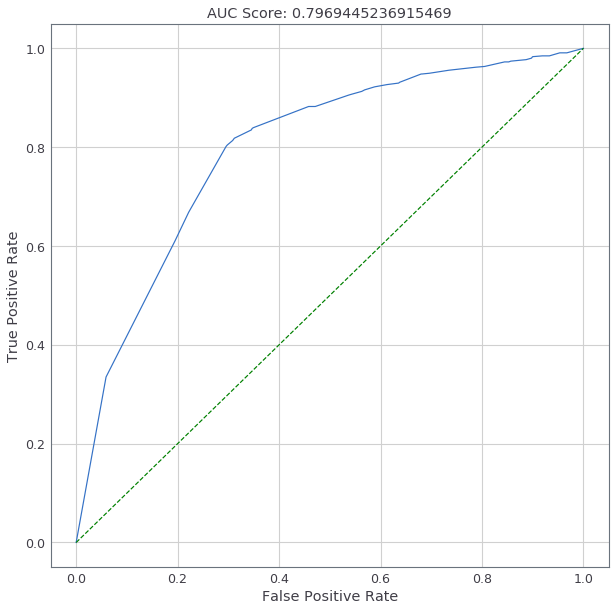

```
cumsum_amount    0.276868
nth_renewal      0.723132
dtype: float64
```

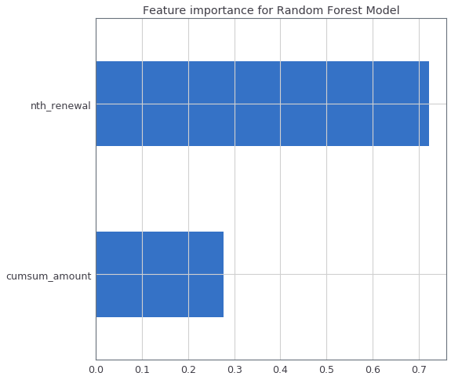

```python
modelname = "Random Forest"

clf = RandomForestClassifier(n_estimators=100,
                             max_depth=6,
                             random_state=100)
clf.fit(X_train, y_train)

score = clf.score(X_test, y_test)

draw_roc_auc(clf, X_test, y_test, modelname, score)
draw_feature_importance(clf.feature_importances_, X_test.columns, modelname)
```

#### Classification metrics

```python
classification_metrics_report(X_test, X_train, y_test, y_train, modelname, True)
```

```
Test data:
```

|  | precision | recall | f1-score | support |
| --- | --- | --- | --- | --- |
| negative class | 0.794189 | 0.805237 | 0.799675 | 1222.000000 |
| positive class | 0.626374 | 0.610092 | 0.618125 | 654.000000 |
| accuracy | 0.737207 | 0.737207 | 0.737207 | 0.737207 |
| macro avg | 0.710281 | 0.707665 | 0.708900 | 1876.000000 |
| weighted avg | 0.735686 | 0.737207 | 0.736384 | 1876.000000 |

```
Train data:
```

|  | precision | recall | f1-score | support |
| --- | --- | --- | --- | --- |
| negative class | 0.823251 | 0.669524 | 0.738472 | 8049.000000 |
| positive class | 0.564434 | 0.748697 | 0.643637 | 4604.000000 |
| accuracy | 0.698332 | 0.698332 | 0.698332 | 0.698332 |
| macro avg | 0.693843 | 0.709110 | 0.691055 | 12653.000000 |
| weighted avg | 0.729076 | 0.698332 | 0.703965 | 12653.000000 |

## Ada Boost

```
Accuracy of Ada Boost model on test data: 0.7398720682302772
```

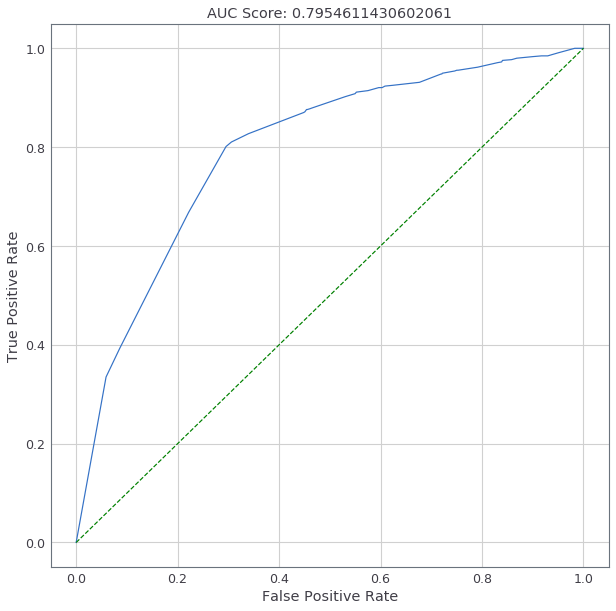

```
cumsum_amount    0.42
nth_renewal      0.58
dtype: float64
```

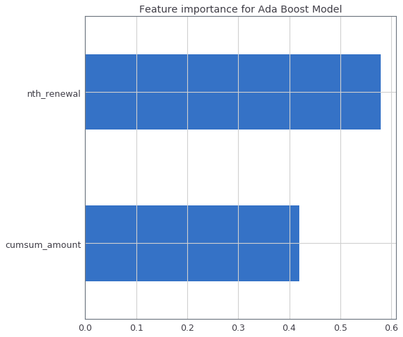

```python
modelname = "Ada Boost"

clf = AdaBoostClassifier(n_estimators=100,
                         random_state=100)
clf.fit(X_train, y_train)

score = clf.score(X_test, y_test)

draw_roc_auc(clf, X_test, y_test, modelname, score)
draw_feature_importance(clf.feature_importances_, X_test.columns, modelname)
```

#### Classification metrics

```python
classification_metrics_report(X_test, X_train, y_test, y_train, modelname, True)
```

```
Test data:
```

|  | precision | recall | f1-score | support |
| --- | --- | --- | --- | --- |
| negative class | 0.814212 | 0.778232 | 0.795816 | 1222.000000 |
| positive class | 0.617232 | 0.668196 | 0.641703 | 654.000000 |
| accuracy | 0.739872 | 0.739872 | 0.739872 | 0.739872 |
| macro avg | 0.715722 | 0.723214 | 0.718760 | 1876.000000 |
| weighted avg | 0.745542 | 0.739872 | 0.742090 | 1876.000000 |

```
Train data:
```

|  | precision | recall | f1-score | support |
| --- | --- | --- | --- | --- |
| negative class | 0.837228 | 0.649894 | 0.731762 | 8049.00000 |
| positive class | 0.560031 | 0.779105 | 0.651649 | 4604.00000 |
| accuracy | 0.696910 | 0.696910 | 0.696910 | 0.69691 |
| macro avg | 0.698630 | 0.714500 | 0.691705 | 12653.00000 |
| weighted avg | 0.736365 | 0.696910 | 0.702611 | 12653.00000 |

## Gradient Boosting

```
Accuracy of Gradient Boosting model on test data: 0.7372068230277186
```

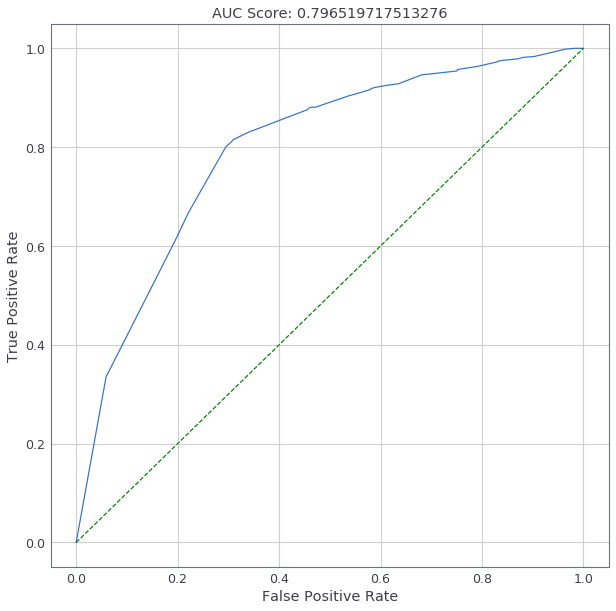

```
cumsum_amount    0.01517
nth_renewal      0.98483
dtype: float64
```

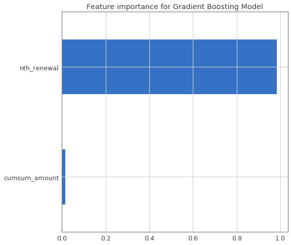

```python
modelname = "Gradient Boosting"

clf = GradientBoostingClassifier(n_estimators=100,
                                 random_state=100,
                                 max_depth=2,
                                 loss='deviance',   # 'deviance', 'exponential'
                                )
clf.fit(X_train, y_train)

score = clf.score(X_test, y_test)

draw_roc_auc(clf, X_test, y_test, modelname, score)
draw_feature_importance(clf.feature_importances_, X_test.columns, modelname)
```

#### Classification metrics

```python
classification_metrics_report(X_test, X_train, y_test, y_train, modelname, True)
```

```
Test data:
```

|  | precision | recall | f1-score | support |
| --- | --- | --- | --- | --- |
| negative class | 0.794189 | 0.805237 | 0.799675 | 1222.000000 |
| positive class | 0.626374 | 0.610092 | 0.618125 | 654.000000 |
| accuracy | 0.737207 | 0.737207 | 0.737207 | 0.737207 |
| macro avg | 0.710281 | 0.707665 | 0.708900 | 1876.000000 |
| weighted avg | 0.735686 | 0.737207 | 0.736384 | 1876.000000 |

```
Train data:
```

|  | precision | recall | f1-score | support |
| --- | --- | --- | --- | --- |
| negative class | 0.823251 | 0.669524 | 0.738472 | 8049.000000 |
| positive class | 0.564434 | 0.748697 | 0.643637 | 4604.000000 |
| accuracy | 0.698332 | 0.698332 | 0.698332 | 0.698332 |
| macro avg | 0.693843 | 0.709110 | 0.691055 | 12653.000000 |
| weighted avg | 0.729076 | 0.698332 | 0.703965 | 12653.000000 |

## Таблица метрик моделей

Теперь построим таблицу собранных метрик и посмотрим на все результаты сразу.

```python
df = pd.DataFrame.from_dict(all_metrics).T.sort_values(by=['AUC'], ascending=False)

df['test_precision_p'] = df['test_p'].apply(lambda x: x['precision'])
df['test_recall_p'] = df['test_p'].apply(lambda x: x['recall'])
df['test_f1_score_p'] = df['test_p'].apply(lambda x: x['f1-score'])

df['train_precision_p'] = df['train_p'].apply(lambda x: x['precision'])
df['train_recall_p'] = df['train_p'].apply(lambda x: x['recall'])
df['train_f1_score_p'] = df['train_p'].apply(lambda x: x['f1-score'])

df['test_precision_n'] = df['test_n'].apply(lambda x: x['precision'])
df['test_recall_n'] = df['test_n'].apply(lambda x: x['recall'])
df['test_f1_score_n'] = df['test_n'].apply(lambda x: x['f1-score'])

df['train_precision_n'] = df['train_n'].apply(lambda x: x['precision'])
df['train_recall_n'] = df['train_n'].apply(lambda x: x['recall'])
df['train_f1_score_n'] = df['train_n'].apply(lambda x: x['f1-score'])

df.drop(['test_p', 'train_p', 'test_n', 'train_n'], axis=1, inplace=True)

df
```

|  | AUC | ACC | test_precision_p | test_recall_p | test_f1_score_p | train_precision_p | train_recall_p | train_f1_score_p | test_precision_n | test_recall_n | test_f1_score_n | train_precision_n | train_recall_n | train_f1_score_n |
| --- | --- | --- | --- | --- | --- | --- | --- | --- | --- | --- | --- | --- | --- | --- |
| Random Forest | 0.796945 | 0.737207 | 0.626374 | 0.610092 | 0.618125 | 0.626374 | 0.610092 | 0.618125 | 0.794189 | 0.805237 | 0.799675 | 0.794189 | 0.805237 | 0.799675 |
| Gradient Boosting | 0.79652 | 0.737207 | 0.626374 | 0.610092 | 0.618125 | 0.626374 | 0.610092 | 0.618125 | 0.794189 | 0.805237 | 0.799675 | 0.794189 | 0.805237 | 0.799675 |
| Decision Tree | 0.795568 | 0.737207 | 0.626374 | 0.610092 | 0.618125 | 0.626374 | 0.610092 | 0.618125 | 0.794189 | 0.805237 | 0.799675 | 0.794189 | 0.805237 | 0.799675 |
| Ada Boost | 0.795461 | 0.739872 | 0.617232 | 0.668196 | 0.641703 | 0.617232 | 0.668196 | 0.641703 | 0.814212 | 0.778232 | 0.795816 | 0.814212 | 0.778232 | 0.795816 |
| Logistic Regression | 0.769222 | 0.657783 | 0.505291 | 0.876147 | 0.640940 | 0.505291 | 0.876147 | 0.640940 | 0.890836 | 0.540917 | 0.673116 | 0.890836 | 0.540917 | 0.673116 |
| MLP | 0.765169 | 0.739872 | 0.617232 | 0.668196 | 0.641703 | 0.617232 | 0.668196 | 0.641703 | 0.814212 | 0.778232 | 0.795816 | 0.814212 | 0.778232 | 0.795816 |
| SVM | 0.763593 | 0.657783 | 0.505291 | 0.876147 | 0.640940 | 0.505291 | 0.876147 | 0.640940 | 0.890836 | 0.540917 | 0.673116 | 0.890836 | 0.540917 | 0.673116 |
| KNearest Neighbors | 0.727599 | 0.716418 | 0.569476 | 0.764526 | 0.652742 | 0.569476 | 0.764526 | 0.652742 | 0.845691 | 0.690671 | 0.760360 | 0.845691 | 0.690671 | 0.760360 |
| Naive Bayes | 0.703137 | 0.681237 | 0.535088 | 0.652905 | 0.588154 | 0.535088 | 0.652905 | 0.588154 | 0.789425 | 0.696399 | 0.740000 | 0.789425 | 0.696399 | 0.740000 |

```python
metrics = ['AUC','ACC','test_precision_p','test_f1_score_p']

for metric in metrics:
    models_list = list(df.sort_values(by=[metric], ascending=False).index[:4])
    print('In {} metrics raiting:'.format(metric))
    print('{}\n'.format(models_list))
```

```
In AUC metrics raiting:
['Random Forest', 'Gradient Boosting', 'Decision Tree', 'Ada Boost']

In ACC metrics raiting:
['Ada Boost', 'MLP', 'Random Forest', 'Gradient Boosting']

In test_precision_p metrics raiting:
['Random Forest', 'Gradient Boosting', 'Decision Tree', 'Ada Boost']

In test_f1_score_p metrics raiting:
['KNearest Neighbors', 'Ada Boost', 'MLP', 'Logistic Regression']
```

*Ada Boost*, *Random Forest*, *Gradient Boosting* и *MLP* показывают лучшие результаты на выбранных метриках, поэтому возьмём их в качестве кандидатов на baseline model

Дальше попробуем построить новые фичи на тех же данных и прогнать выбранные модели на новом датасете

## Feature Engineering

```python
# за сколько дней до очередного продления подписки произошла оплата
def get_startdate_minus_paydate(x):
    return (x['start_date'].to_pydatetime() - x['pay_date'].to_pydatetime()).days

# спустя сколько месяцев после регистрации произошла оплата очередной подписки
def get_paydate_minus_regdate(x):
    return (x['pay_date'].to_pydatetime() - x['regdate'].to_pydatetime()).days / 30

# день недели, когда заканчивается подписка
def get_weekday(x):
    return x['expiration_date'].to_pydatetime().weekday() / 7

# месяц / сезон года, когда заканчивается подписка
def get_month(x):
    return x['expiration_date'].to_pydatetime().month / 4

# день месяца, когда заканчивается подписка
def get_monthday(x):
    return x['expiration_date'].to_pydatetime().day / 30

# год, когда заканчивается подписка
def get_year(x):
    return x['expiration_date'].to_pydatetime().year

# добавить в таблицу кол-во сервисов у пользователя на текущий момент
def add_num_services(df):
    users = df["user_id"].values
    df["nservices"] = 0
    for u in users:
        _df = df[df["user_id"] == u]
        g = _df.groupby(by=["service_id"])
        service_ids = list(g.groups.keys())
        for n,s in enumerate(service_ids):
            idx = df[(df["user_id"] == u) & (df["service_id"] == s)].index
            df.at[idx, "nservices"] = n + 1
    return df
```

## Чтение данных и добавление новых features

```python
# чтение данных
# история транзакций
df_history = pd.read_csv("history.csv", parse_dates=["pay_date", "start_date", "expiration_date", "on_date"])
# отложенная выборка
df_test = pd.read_csv("test.csv", parse_dates=["on_date"])
# информация о клиентах
df_users = pd.read_csv("users.csv", parse_dates=["regdate"])

# выделение признаков из истории транзакций по конкретной услуге
def get_features(df):
    df = add_num_services(df)
    df["cumsum_amount"] = df["amount"].cumsum()
    df["regdate"] = df["user_id"].apply(lambda x: df_users[df_users["user_id"] == x]["regdate"].values[0])
    df["start_minus_pay"] = df.apply(get_startdate_minus_paydate, axis=1)
    df["season"] = df.apply(get_month, axis=1)
    df["pay_minus_reg"] = df.apply(get_paydate_minus_regdate, axis=1)
    return df

# сортировка по времени, группировка по услугам, выделение признаков
df_history = df_history\
    .sort_values(["service_id", "pay_date", "start_date"])\
    .groupby("service_id")\
    .apply(get_features)

# разделение истории на обучающую и тестовую выборку
df_history["test"] = df_history["churn"].isnull()

# используемые признаки
used_cols = ["nth_renewal", "cumsum_amount", "start_minus_pay", "pay_minus_reg", "season", "nservices"]
# целевой признак
target_col = "churn"

# обучающая выборка
X_train = df_history.query("~test")[used_cols]
y_train = df_history.query("~test")[target_col]
# тестовая (отложенная) выборка
X_test = df_history.query("test")[used_cols]
y_test = df_test[target_col]
```

Скрипт выше написан на основе примера, представленного в файлах задания. Он добавляет новые features и готовит данные

Посмотрим как выглядят данные теперь

```python
X_train.head()
```

|  | nth_renewal | cumsum_amount | start_minus_pay | pay_minus_reg | season | nservices |
| --- | --- | --- | --- | --- | --- | --- |
| 1876 | 0 | 1 | 0 | 12.766667 | 1.50 | 1 |
| 1877 | 0 | 3 | 0 | 0.000000 | 2.00 | 1 |
| 1878 | 1 | 4 | 1 | 3.033333 | 2.25 | 1 |
| 1879 | 2 | 5 | 7 | 3.866667 | 2.50 | 1 |
| 1880 | 3 | 6 | 0 | 5.600000 | 2.75 | 1 |

**start_minus_pay** - данные о том, за сколько дней до очередного продления подписки произошла оплата

**pay_minus_reg** - данные о том, сколько месяцев после регистрации произошла оплата очередной подписки

**nservices** - данные о количестве сервисов у пользователя

Опробуем добавленные данные на выбранных моделях

## Ada Boost

```
Accuracy of Ada Boost Classifier model on test data: 0.7430703624733476
```

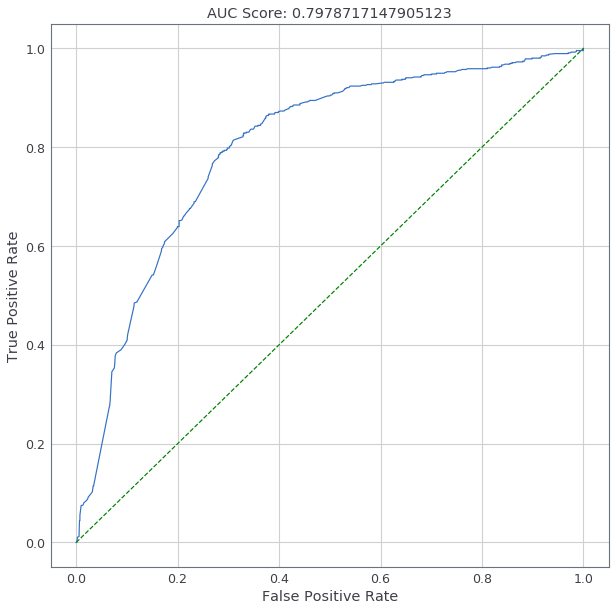

```
nservices          0.00
cumsum_amount      0.06
season             0.11
nth_renewal        0.14
start_minus_pay    0.15
pay_minus_reg      0.54
dtype: float64
```

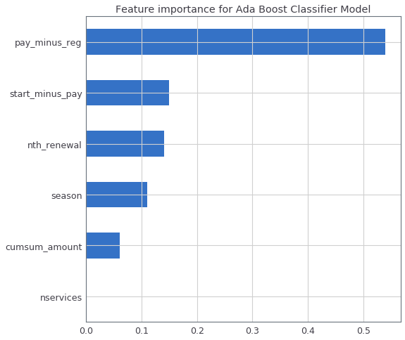

```python
modelname = "Ada Boost Classifier"

clf = AdaBoostClassifier(n_estimators=100,
                         random_state=100)
clf.fit(X_train, y_train)

score = clf.score(X_test, y_test)

print("Accuracy of {} model on test data: {}".format(modelname, score))

draw_roc_auc(clf, X_test, y_test)
draw_feature_importance(clf.feature_importances_, X_test.columns, modelname)
```

```python
classification_metrics_report(X_test, X_train, y_test, y_train, modelname, False)
```

```
Test data:
```

|  | precision | recall | f1-score | support |
| --- | --- | --- | --- | --- |
| negative class | 0.812500 | 0.787234 | 0.799667 | 1222.00000 |
| positive class | 0.624277 | 0.660550 | 0.641902 | 654.00000 |
| accuracy | 0.743070 | 0.743070 | 0.743070 | 0.74307 |
| macro avg | 0.718389 | 0.723892 | 0.720785 | 1876.00000 |
| weighted avg | 0.746883 | 0.743070 | 0.744668 | 1876.00000 |

```
Train data:
```

|  | precision | recall | f1-score | support |
| --- | --- | --- | --- | --- |
| negative class | 0.816305 | 0.687912 | 0.746629 | 8049.000000 |
| positive class | 0.572061 | 0.729366 | 0.641207 | 4604.000000 |
| accuracy | 0.702995 | 0.702995 | 0.702995 | 0.702995 |
| macro avg | 0.694183 | 0.708639 | 0.693918 | 12653.000000 |
| weighted avg | 0.727433 | 0.702995 | 0.708269 | 12653.000000 |

## Random Forest

```
Accuracy of Random Forest model on test data: 0.7409381663113006
```

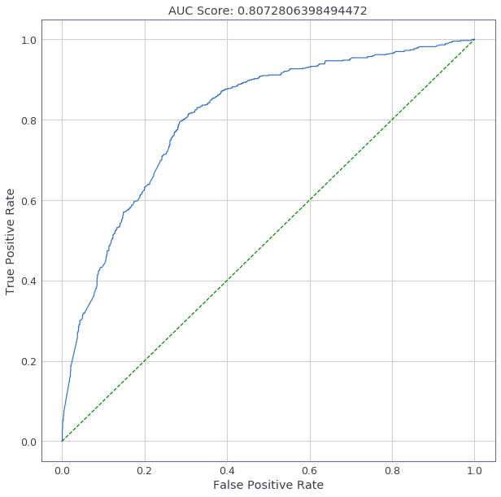

```
nservices          0.000000
season             0.039679
pay_minus_reg      0.115881
cumsum_amount      0.150065
start_minus_pay    0.204625
nth_renewal        0.489751
dtype: float64
```

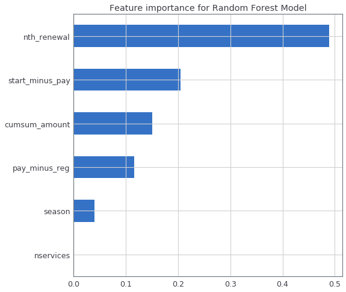

```python
modelname = "Random Forest"

clf = RandomForestClassifier(n_estimators=100,
                             max_depth=6,
                             random_state=100)
clf.fit(X_train, y_train)

score = clf.score(X_test, y_test)
print("Accuracy of {} model on test data: {}".format(modelname, score))

draw_roc_auc(clf, X_test, y_test)
draw_feature_importance(clf.feature_importances_, X_test.columns, modelname)
```

```python
classification_metrics_report(X_test, X_train, y_test, y_train, modelname, False)
```

```
Test data:
```

|  | precision | recall | f1-score | support |
| --- | --- | --- | --- | --- |
| negative class | 0.791601 | 0.817512 | 0.804348 | 1222.000000 |
| positive class | 0.636808 | 0.597859 | 0.616719 | 654.000000 |
| accuracy | 0.740938 | 0.740938 | 0.740938 | 0.740938 |
| macro avg | 0.714204 | 0.707686 | 0.710534 | 1876.000000 |
| weighted avg | 0.737638 | 0.740938 | 0.738938 | 1876.000000 |

```
Train data:
```

|  | precision | recall | f1-score | support |
| --- | --- | --- | --- | --- |
| negative class | 0.821097 | 0.703069 | 0.757513 | 8049.000000 |
| positive class | 0.585141 | 0.732189 | 0.650458 | 4604.000000 |
| accuracy | 0.713665 | 0.713665 | 0.713665 | 0.713665 |
| macro avg | 0.703119 | 0.717629 | 0.703986 | 12653.000000 |
| weighted avg | 0.735241 | 0.713665 | 0.718559 | 12653.000000 |

## Gradient Boosting

```
Accuracy of Gradient Boosting model on test data: 0.7452025586353944
```

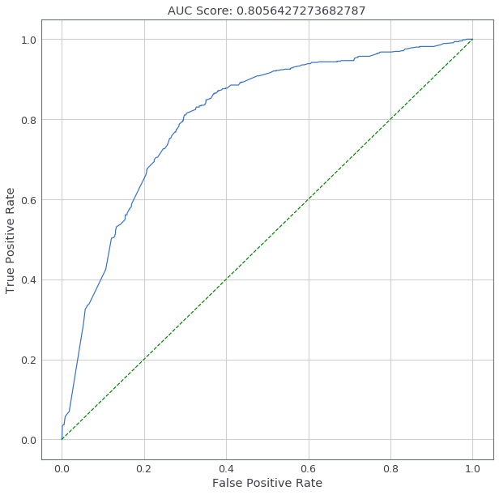

```
nservices          0.000000
cumsum_amount      0.012003
season             0.017503
pay_minus_reg      0.039133
start_minus_pay    0.067955
nth_renewal        0.863407
dtype: float64
```

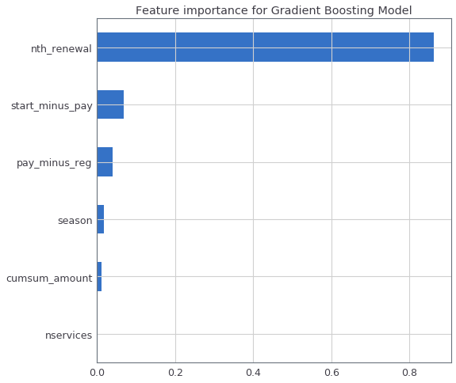

```python
modelname = "Gradient Boosting"

clf = GradientBoostingClassifier(n_estimators=100,
                                 random_state=100,
                                 max_depth=2,
                                 loss='deviance',   # 'deviance', 'exponential'
                                )
clf.fit(X_train, y_train)

score = clf.score(X_test, y_test)
print("Accuracy of {} model on test data: {}".format(modelname, score))

draw_roc_auc(clf, X_test, y_test)
draw_feature_importance(clf.feature_importances_, X_test.columns, modelname)
```

```python
classification_metrics_report(X_test, X_train, y_test, y_train, modelname, False)
```

```
Test data:
```

|  | precision | recall | f1-score | support |
| --- | --- | --- | --- | --- |
| negative class | 0.829204 | 0.766776 | 0.796769 | 1222.000000 |
| positive class | 0.617962 | 0.704893 | 0.658571 | 654.000000 |
| accuracy | 0.745203 | 0.745203 | 0.745203 | 0.745203 |
| macro avg | 0.723583 | 0.735834 | 0.727670 | 1876.000000 |
| weighted avg | 0.755562 | 0.745203 | 0.748591 | 1876.000000 |

```
Train data:
```

|  | precision | recall | f1-score | support |
| --- | --- | --- | --- | --- |
| negative class | 0.806336 | 0.698845 | 0.748752 | 8049.000000 |
| positive class | 0.573014 | 0.706560 | 0.632818 | 4604.000000 |
| accuracy | 0.701652 | 0.701652 | 0.701652 | 0.701652 |
| macro avg | 0.689675 | 0.702702 | 0.690785 | 12653.000000 |
| weighted avg | 0.721438 | 0.701652 | 0.706568 | 12653.000000 |

## MLP

```
Accuracy of MLP model on test data: 0.7425373134328358
```

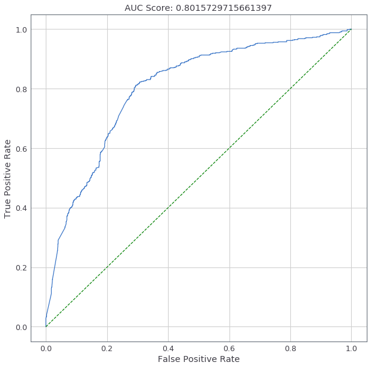

```
nth_renewal       -956.946971
start_minus_pay   -231.772159
pay_minus_reg      -77.399666
season              63.619053
cumsum_amount       73.785005
nservices          199.939154
dtype: float64
```

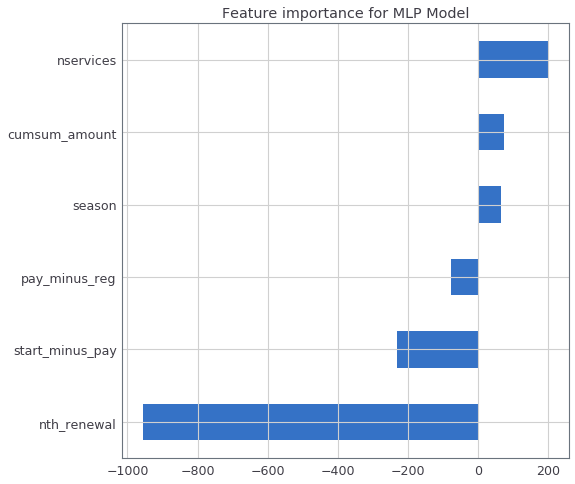

```python
modelname = "MLP"

clf = MLPClassifier(hidden_layer_sizes=(100,50),
                    activation='logistic', #'logistic',# 'relu'
                    solver='adam',#'adam', 'sgd'
                    alpha=0.0001,
                    batch_size='auto',
                    learning_rate='invscaling',# 'constant', 'adaptive', 'invscaling'
                    learning_rate_init=0.05,
                    power_t=0.5,
                    max_iter=100000,
                    shuffle=True,
                    random_state=100,
                    tol=0.001,
                    verbose=False,
                    warm_start=True,
                    momentum=0.9,
                    nesterovs_momentum=True,
                    early_stopping=False,
                    validation_fraction=0.1,
                    beta_1=0.9,
                    beta_2=0.999,
                    epsilon=1e-08)

clf.fit(X_train, y_train)

score = clf.score(X_test, y_test)

print("Accuracy of {} model on test data: {}".format(modelname, score))

draw_roc_auc(clf, X_test, y_test)
W0, W1, W2 = clf.coefs_
draw_feature_importance(W0.dot(W1).dot(W2), X_test.columns, modelname)
```

```python
classification_metrics_report(X_test, X_train, y_test, y_train, modelname, False)
```

```
Test data:
```

|  | precision | recall | f1-score | support |
| --- | --- | --- | --- | --- |
| negative class | 0.806131 | 0.796236 | 0.801153 | 1222.000000 |
| positive class | 0.627803 | 0.642202 | 0.634921 | 654.000000 |
| accuracy | 0.742537 | 0.742537 | 0.742537 | 0.742537 |
| macro avg | 0.716967 | 0.719219 | 0.718037 | 1876.000000 |
| weighted avg | 0.743963 | 0.742537 | 0.743202 | 1876.000000 |

```
Train data:
```

|  | precision | recall | f1-score | support |
| --- | --- | --- | --- | --- |
| negative class | 0.747096 | 0.783203 | 0.764724 | 8049.000000 |
| positive class | 0.586002 | 0.536490 | 0.560154 | 4604.000000 |
| accuracy | 0.693432 | 0.693432 | 0.693432 | 0.693432 |
| macro avg | 0.666549 | 0.659846 | 0.662439 | 12653.000000 |
| weighted avg | 0.688480 | 0.693432 | 0.690288 | 12653.000000 |

## Заключение

По результатам можно заметить несколько закономерностей: чем больше у пользователя сервисов, тем более вероятно, что он не продлит подписку; чем больше количество обновлений, тем меньше вероятность, что пользователь отпишется; чем раньше пользователь оплачивает сервис, тем меньше вероятность, что пользователь отпишется

А по *precision* - *Random Forest* и *MLP*

MLP не подходит для решения задачи, если важна интерпретируемость.

Вероятно, такие данные, как тип продукта или тип клиента могут значительно улучшить качество предсказаний модели.

Вероятно, соединение лучших моделей из эксперимента в ансамбль так же может улучшить качество предсказаний.

*PS*

Забавное наблюдение, на разных компьютерах с разными версиями python и sklearn (py36 sk19 на ноутбуке и py37 sk21 на рабочем компьютере) влияют на разницу в показаниях, в частности точность предсказаний модели MLP на рабочем компьютере на 1% хуже, чем на ноутбуке